# Twitter Analysis

Progress Journals - Extended Tutorials

May 7, 2019

In this short tutorial we are going to learn how to obtain and analyze tweets using `rtweet` and `tidytext` packages. Our data of interest will be Good Omens tweets. Let’s start with some prerequisites.

## Initialization

Load (and if not installed, install) the following packages.

```r
options(stringsAsFactors=FALSE)
library(plyr)
library(tidyverse)
library(lubridate)
library(rtweet)
library(tidytext)
library(wordcloud)
```

Using `create_token` function, set your Twitter credentials. Replace the placeholders with your actual info.

```r
  create_token(
    app = "APP_NAME",
    consumer_key = "CONSUMER_KEY",
    consumer_secret = "CONSUMER_SECRET",
    access_token = "ACCESS_TOKEN",
    access_secret = "ACCESS_SECRET"
  )
```

Now, you are ready to analyze data!

## Getting Data from Twitter

Let’s get 5000 tweets in English with `#GoodOmens` hashtag. Exclude retweets by setting `include_rts` parameter to `FALSE`.

```r
tweets_raw <- search_tweets("#GoodOmens", n = 5000, include_rts = FALSE, lang = "en",retryonratelimit = TRUE)
```

Let’s check the gathered information. In this query we have a data frame of 811 rows and 88 columns.

```r
glimpse(tweets_raw)
```

```
## Observations: 811
## Variables: 88
## $ user_id                 <chr> "1705880828", "60402504", "60402504", "6…
## $ status_id               <chr> "1125638204433080321", "1125633990721822…
## $ created_at              <dttm> 2019-05-07 05:47:15, 2019-05-07 05:30:3…
## $ screen_name             <chr> "ForxGood", "GDgeek", "GDgeek", "GDgeek"…
## $ text                    <chr> "Catch me not leaving the house May 31st…
## $ source                  <chr> "Twitter for iPhone", "Twitter for iPhon…
## $ display_text_width      <dbl> 50, 24, 122, 59, 49, 45, 63, 204, 175, 1…
## $ reply_to_status_id      <chr> NA, "1125611208936165376", NA, "11237044…
## $ reply_to_user_id        <chr> NA, "2842820572", NA, "10268428762847559…
## $ reply_to_screen_name    <chr> NA, "Caeroliine", NA, "HieronymusMcG", "…
## $ is_quote                <lgl> TRUE, FALSE, FALSE, FALSE, FALSE, FALSE,…
## $ is_retweet              <lgl> FALSE, FALSE, FALSE, FALSE, FALSE, FALSE…
## $ favorite_count          <int> 0, 0, 5, 6, 3, 6, 3, 0, 5, 6, 2, 3, 3, 5…
```

[output cut: 75 more lines]

Before we dive into text analysis, let’s do some preliminary checks. Let’s see the top 10 Tweeters for this patch.

```r
tweets_raw %>% count(screen_name,sort=TRUE) %>% slice(1:10) %>% knitr::kable()
```

| screen_name | n |
| --- | --- |
| GoodOmensPrime | 121 |
| RU_fandom_GO | 25 |
| TJBrownauthor | 22 |
| FYeahGoodOmens | 19 |
| Caeroliine | 12 |
| RikeWunsch | 10 |
| davidtennantcom | 8 |
| ldlapinski | 8 |
| Worgi | 7 |
| Alrightpunk | 6 |

Top 10 places people are tweeting from.

```r
tweets_raw %>%
  filter(!is.na(place_full_name)) %>%
  distinct(user_id,.keep_all = TRUE) %>%
  count(place_full_name,sort=TRUE) %>% slice(1:10) %>% knitr::kable()
```

| place_full_name | n |
| --- | --- |
| Birmingham, AL | 1 |
| Brent, London | 1 |
| California, USA | 1 |
| Camden Town, London | 1 |
| Croydon, London | 1 |
| Helsinki, Finland | 1 |
| Jefferson City, MO | 1 |
| Karlsruhe, Germany | 1 |
| London, Ontario | 1 |
| Los Angeles, CA | 1 |

Average favs and retweets per tweet.

```r
tweets_raw %>% summarise_at(vars(favorite_count,retweet_count),list(~round(mean(.)))) %>% knitr::kable()
```

| favorite_count | retweet_count |
| --- | --- |
| 28 | 4 |

## Text Mining

With several simple commands we will clean up Twitter chatter while maintaining Twitter properties such as mentions and hashtags. Using `unnest_tokens` we separated tweets into single words. By filtering stop words, we removed all irrelevant words that are essential to build a grammatically correct sentence. Then we do a word count to get the most popular words.

```r
tweet_words <-
tweets_raw %>%
  select(text) %>%
  unnest_tokens(word,text,token = "tweets") %>%
  filter(!word %in% stop_words$word,
         !word %in% str_remove_all(stop_words$word, "'"),
         str_detect(word, "[a-z]"))

tweet_words %>% count(word,sort=TRUE) %>% slice(1:20) %>% knitr::kable()
```

| word | n |
| --- | --- |
| #goodomens | 834 |
| @neilhimself | 166 |
| @goodomensprime | 96 |
| book | 68 |
| time | 60 |
| omens | 57 |
| @terryandrob | 53 |
| read | 49 |
| month | 45 |
| days | 44 |
| wait | 44 |
| crowley | 41 |
| love | 40 |
| #davidtennant | 37 |
| excited | 35 |
| @michaelsheen | 34 |
| aziraphale | 33 |
| series | 31 |
| 31st | 30 |
| apocalypse | 30 |

While we are at it, let’s create a classic wordcloud.

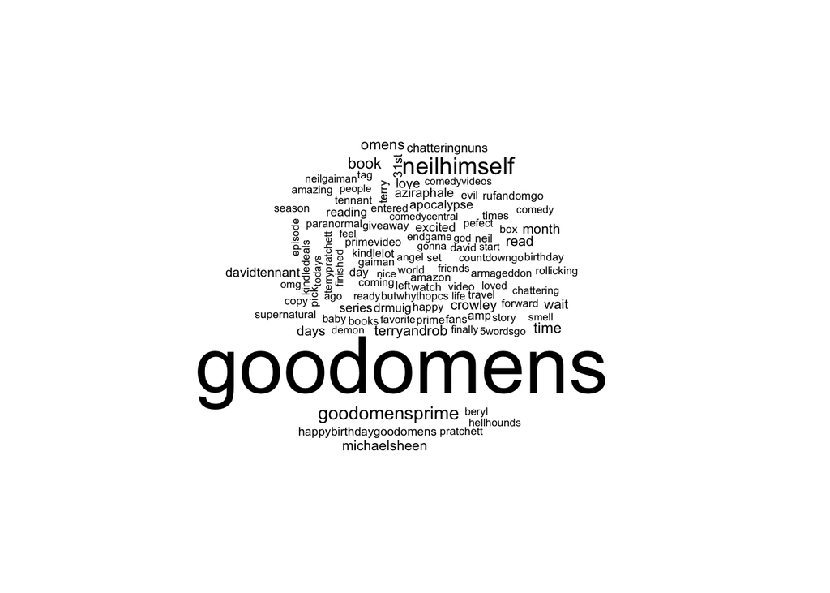

```r
wordcloud(tweet_words$word,max.words = 100)
```

## Sentiment Analysis

Sentiment analysis with tidytext is easy because of predefined libraries. Though you should be aware that not every sentiment library is useful to your data set. Here we are going to use “Bing”" sentiments with only negative and positive outcomes.

```r
sentiments %>% filter(lexicon=="bing") %>% slice(1:10) %>% knitr::kable()
```

| word | sentiment | lexicon | score |
| --- | --- | --- | --- |
| 2-faced | negative | bing | NA |
| 2-faces | negative | bing | NA |
| a+ | positive | bing | NA |
| abnormal | negative | bing | NA |
| abolish | negative | bing | NA |
| abominable | negative | bing | NA |
| abominably | negative | bing | NA |
| abominate | negative | bing | NA |
| abomination | negative | bing | NA |
| abort | negative | bing | NA |

```r
sentiment_words <-
tweet_words %>%
  left_join(.,
    sentiments %>% filter(lexicon=="bing") %>% select(word,sentiment),
    by="word"
  ) %>%
  filter(!is.na(sentiment))

sentiment_words %>% slice(1:10) %>% knitr::kable()
```

| word | sentiment |
| --- | --- |
| damned | negative |
| ready | positive |
| excited | positive |
| love | positive |
| demon | negative |
| angel | positive |
| negative | negative |
| enjoyed | positive |
| excited | positive |
| stylish | positive |

Now let’s finish this short analysis with another wordcloud. This time we are going to separate sentiments into two groups.

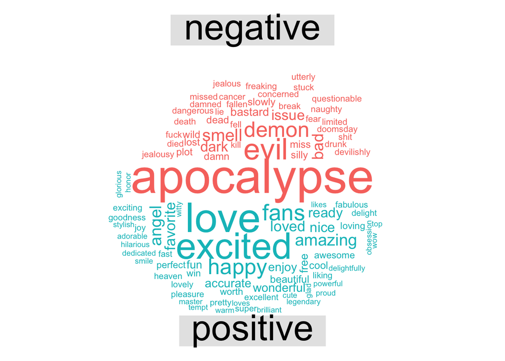

```r
sentiment_frequency <-
sentiment_words %>%
  count(word,sentiment) %>%
  spread(sentiment,n,fill=0)

sentiment_matrix <-
sentiment_frequency %>%
  select(-word) %>%
  as.matrix(.)

rownames(sentiment_matrix) <- sentiment_frequency$word

comparison.cloud(sentiment_matrix,colors = c("#F8766D", "#00BFC4"),
                 max.words = 100)
```

## References

For further information, you can check the following amazing sources.

- [rtweet package official page](https://rtweet.info/)
- [tidytext package official page](https://www.tidytextmining.com/)
- [Colin Fay’s blog posts](https://colinfay.me/rtweet-tidytext/)